# Part I - Ford GoBike System Data

## Introduction

> This data set includes information about individual rides made in a bike-sharing system covering the greater San Francisco Bay area.

## Preliminary Wrangling

```python
# import all packages and set plots to be embedded inline
import numpy as np
import pandas as pd
import matplotlib.pyplot as plt
import seaborn as sns
import time

%matplotlib inline
```

```python
#load dataset

bike = pd.read_csv('201902-fordgobike-tripdata.csv')
```

```python
#view dataset

bike
```

|  | duration_sec | start_time | end_time | start_station_id | start_station_name | start_station_latitude | start_station_longitude | end_station_id | end_station_name | end_station_latitude | end_station_longitude | bike_id | user_type | member_birth_year | member_gender | bike_share_for_all_trip |
| --- | --- | --- | --- | --- | --- | --- | --- | --- | --- | --- | --- | --- | --- | --- | --- | --- |
| 0 | 52185 | 2019-02-28 17:32:10.1450 | 2019-03-01 08:01:55.9750 | 21.0 | Montgomery St BART Station (Market St at 2nd St) | 37.789625 | -122.400811 | 13.0 | Commercial St at Montgomery St | 37.794231 | -122.402923 | 4902 | Customer | 1984.0 | Male | No |
| 1 | 42521 | 2019-02-28 18:53:21.7890 | 2019-03-01 06:42:03.0560 | 23.0 | The Embarcadero at Steuart St | 37.791464 | -122.391034 | 81.0 | Berry St at 4th St | 37.775880 | -122.393170 | 2535 | Customer | NaN | NaN | No |
| 2 | 61854 | 2019-02-28 12:13:13.2180 | 2019-03-01 05:24:08.1460 | 86.0 | Market St at Dolores St | 37.769305 | -122.426826 | 3.0 | Powell St BART Station (Market St at 4th St) | 37.786375 | -122.404904 | 5905 | Customer | 1972.0 | Male | No |
| 3 | 36490 | 2019-02-28 17:54:26.0100 | 2019-03-01 04:02:36.8420 | 375.0 | Grove St at Masonic Ave | 37.774836 | -122.446546 | 70.0 | Central Ave at Fell St | 37.773311 | -122.444293 | 6638 | Subscriber | 1989.0 | Other | No |
| 4 | 1585 | 2019-02-28 23:54:18.5490 | 2019-03-01 00:20:44.0740 | 7.0 | Frank H Ogawa Plaza | 37.804562 | -122.271738 | 222.0 | 10th Ave at E 15th St | 37.792714 | -122.248780 | 4898 | Subscriber | 1974.0 | Male | Yes |
| ... | ... | ... | ... | ... | ... | ... | ... | ... | ... | ... | ... | ... | ... | ... | ... | ... |
| 183407 | 480 | 2019-02-01 00:04:49.7240 | 2019-02-01 00:12:50.0340 | 27.0 | Beale St at Harrison St | 37.788059 | -122.391865 | 324.0 | Union Square (Powell St at Post St) | 37.788300 | -122.408531 | 4832 | Subscriber | 1996.0 | Male | No |
| 183408 | 313 | 2019-02-01 00:05:34.7440 | 2019-02-01 00:10:48.5020 | 21.0 | Montgomery St BART Station (Market St at 2nd St) | 37.789625 | -122.400811 | 66.0 | 3rd St at Townsend St | 37.778742 | -122.392741 | 4960 | Subscriber | 1984.0 | Male | No |
| 183409 | 141 | 2019-02-01 00:06:05.5490 | 2019-02-01 00:08:27.2200 | 278.0 | The Alameda at Bush St | 37.331932 | -121.904888 | 277.0 | Morrison Ave at Julian St | 37.333658 | -121.908586 | 3824 | Subscriber | 1990.0 | Male | Yes |
| 183410 | 139 | 2019-02-01 00:05:34.3600 | 2019-02-01 00:07:54.2870 | 220.0 | San Pablo Ave at MLK Jr Way | 37.811351 | -122.273422 | 216.0 | San Pablo Ave at 27th St | 37.817827 | -122.275698 | 5095 | Subscriber | 1988.0 | Male | No |
| 183411 | 271 | 2019-02-01 00:00:20.6360 | 2019-02-01 00:04:52.0580 | 24.0 | Spear St at Folsom St | 37.789677 | -122.390428 | 37.0 | 2nd St at Folsom St | 37.785000 | -122.395936 | 1057 | Subscriber | 1989.0 | Male | No |

183412 rows × 16 columns

### Visual & Programmatic Assesment

```python
#check data structure

bike.shape
```

```
(183412, 16)
```

> The dataset has **183412** rows/observations & **16** columns/variables

```python
#check columns structure/general description of dataset

bike.info()
```

```
<class 'pandas.core.frame.DataFrame'>
RangeIndex: 183412 entries, 0 to 183411
Data columns (total 16 columns):
 #   Column                   Non-Null Count   Dtype
---  ------                   --------------   -----
 0   duration_sec             183412 non-null  int64
 1   start_time               183412 non-null  object
 2   end_time                 183412 non-null  object
 3   start_station_id         183215 non-null  float64
 4   start_station_name       183215 non-null  object
 5   start_station_latitude   183412 non-null  float64
 6   start_station_longitude  183412 non-null  float64
 7   end_station_id           183215 non-null  float64
 8   end_station_name         183215 non-null  object
 9   end_station_latitude     183412 non-null  float64
 10  end_station_longitude    183412 non-null  float64
 11  bike_id                  183412 non-null  int64
 12  user_type                183412 non-null  object
 13  member_birth_year        175147 non-null  float64
 14  member_gender            175147 non-null  object
 15  bike_share_for_all_trip  183412 non-null  object
dtypes: float64(7), int64(2), object(7)
memory usage: 22.4+ MB
```

#### From the above the dataset has the following issues:

- Missing/Null values in:

  > **start_station_id**, **start_station_name**, **end_station_id**, **end_station_name**, **member_gender**, **member_birth_year**
- **start_time** as **object** instead of **datetime**
- **end_time** as **object** instead of **datetime**
- **start_station_id** as **float64** instead of **int64**
- **end_station_id** as **float64** instead of **int64**
- **user_type** as **object** instead of **category**
- **member_birth_year** as **float64** instead of **int64**
- **member_gender** as **object** intead of **category**
- **bike_share_for_all_trip** as **object** instead of **category**

```python
#total number of missing values in each columns

missing_val_cols = ['start_station_id', 'start_station_name', 'end_station_id',
               'end_station_name', 'member_gender', 'member_birth_year']

for i in missing_val_cols:
    print(i, 'has', bike[i].isnull().sum(), 'missing values')
```

```
start_station_id has 197 missing values
start_station_name has 197 missing values
end_station_id has 197 missing values
end_station_name has 197 missing values
member_gender has 8265 missing values
member_birth_year has 8265 missing values
```

```python
#unique value for user_type

bike['user_type'].value_counts()
```

```
Subscriber    163544
Customer       19868
Name: user_type, dtype: int64
```

```python
#unique value for member_gender

bike['member_gender'].value_counts()
```

```
Male      130651
Female     40844
Other       3652
Name: member_gender, dtype: int64
```

```python
#unique value for bike_share_for_all_trip

bike['bike_share_for_all_trip'].value_counts()
```

```
No     166053
Yes     17359
Name: bike_share_for_all_trip, dtype: int64
```

### Cleaning the identified data issues

```python
#create a copy of original dataset

bike_clean = bike.copy()
```

```python
#view new dataest

bike_clean.head(3)
```

|  | duration_sec | start_time | end_time | start_station_id | start_station_name | start_station_latitude | start_station_longitude | end_station_id | end_station_name | end_station_latitude | end_station_longitude | bike_id | user_type | member_birth_year | member_gender | bike_share_for_all_trip |
| --- | --- | --- | --- | --- | --- | --- | --- | --- | --- | --- | --- | --- | --- | --- | --- | --- |
| 0 | 52185 | 2019-02-28 17:32:10.1450 | 2019-03-01 08:01:55.9750 | 21.0 | Montgomery St BART Station (Market St at 2nd St) | 37.789625 | -122.400811 | 13.0 | Commercial St at Montgomery St | 37.794231 | -122.402923 | 4902 | Customer | 1984.0 | Male | No |
| 1 | 42521 | 2019-02-28 18:53:21.7890 | 2019-03-01 06:42:03.0560 | 23.0 | The Embarcadero at Steuart St | 37.791464 | -122.391034 | 81.0 | Berry St at 4th St | 37.775880 | -122.393170 | 2535 | Customer | NaN | NaN | No |
| 2 | 61854 | 2019-02-28 12:13:13.2180 | 2019-03-01 05:24:08.1460 | 86.0 | Market St at Dolores St | 37.769305 | -122.426826 | 3.0 | Powell St BART Station (Market St at 4th St) | 37.786375 | -122.404904 | 5905 | Customer | 1972.0 | Male | No |

```python
#columns with missing values

bike_clean.isnull().sum()
```

```
duration_sec                  0
start_time                    0
end_time                      0
start_station_id            197
start_station_name          197
start_station_latitude        0
start_station_longitude       0
end_station_id              197
end_station_name            197
end_station_latitude          0
end_station_longitude         0
bike_id                       0
user_type                     0
member_birth_year          8265
member_gender              8265
bike_share_for_all_trip       0
dtype: int64
```

```python
#print columns and missing values count

station_cols = ['start_station_id', 'start_station_name', 'end_station_id', 'end_station_name']

for i in station_cols:
    print(i, 'has', bike_clean[i].isnull().sum(), 'missing values')
```

```
start_station_id has 197 missing values
start_station_name has 197 missing values
end_station_id has 197 missing values
end_station_name has 197 missing values
```

> I suspect the **start_station_id**, **start_station_name**, **end_station_id** & **end_station_name** has missing values in the same rows  
> If this is True I'll be dropping the rows in both columns

```python
#testing if the above is True

bike_clean[bike_clean['start_station_id'].isnull() & bike_clean['start_station_name'].isnull()
          & bike_clean['end_station_id'].isnull()& bike_clean['end_station_name'].isnull()]
```

|  | duration_sec | start_time | end_time | start_station_id | start_station_name | start_station_latitude | start_station_longitude | end_station_id | end_station_name | end_station_latitude | end_station_longitude | bike_id | user_type | member_birth_year | member_gender | bike_share_for_all_trip |
| --- | --- | --- | --- | --- | --- | --- | --- | --- | --- | --- | --- | --- | --- | --- | --- | --- |
| 475 | 1709 | 2019-02-28 20:55:53.9320 | 2019-02-28 21:24:23.7380 | NaN | NaN | 37.40 | -121.94 | NaN | NaN | 37.40 | -121.93 | 4211 | Customer | 1991.0 | Female | No |
| 1733 | 1272 | 2019-02-28 18:32:34.2730 | 2019-02-28 18:53:46.7270 | NaN | NaN | 37.40 | -121.94 | NaN | NaN | 37.41 | -121.96 | 4174 | Subscriber | 1980.0 | Male | No |
| 3625 | 142 | 2019-02-28 17:10:46.5290 | 2019-02-28 17:13:09.4310 | NaN | NaN | 37.41 | -121.95 | NaN | NaN | 37.41 | -121.96 | 4283 | Subscriber | 1988.0 | Male | No |
| 4070 | 585 | 2019-02-28 16:28:45.9340 | 2019-02-28 16:38:31.3320 | NaN | NaN | 37.39 | -121.93 | NaN | NaN | 37.40 | -121.92 | 4089 | Subscriber | 1984.0 | Male | Yes |
| 5654 | 509 | 2019-02-28 12:30:17.1310 | 2019-02-28 12:38:46.3290 | NaN | NaN | 37.40 | -121.92 | NaN | NaN | 37.39 | -121.93 | 4089 | Subscriber | 1984.0 | Male | Yes |
| ... | ... | ... | ... | ... | ... | ... | ... | ... | ... | ... | ... | ... | ... | ... | ... | ... |
| 176154 | 1447 | 2019-02-02 12:03:04.5440 | 2019-02-02 12:27:12.2670 | NaN | NaN | 37.40 | -121.93 | NaN | NaN | 37.40 | -121.93 | 4249 | Customer | 1984.0 | Male | No |
| 179730 | 309 | 2019-02-01 12:59:45.9690 | 2019-02-01 13:04:55.4260 | NaN | NaN | 37.40 | -121.94 | NaN | NaN | 37.40 | -121.93 | 4249 | Customer | 1987.0 | Female | No |
| 179970 | 659 | 2019-02-01 12:17:37.6750 | 2019-02-01 12:28:37.0140 | NaN | NaN | 37.41 | -121.96 | NaN | NaN | 37.41 | -121.94 | 4092 | Subscriber | 1999.0 | Female | No |
| 180106 | 2013 | 2019-02-01 11:33:55.1470 | 2019-02-01 12:07:28.9400 | NaN | NaN | 37.40 | -121.94 | NaN | NaN | 37.40 | -121.94 | 4251 | Customer | 1990.0 | Female | No |
| 181201 | 312 | 2019-02-01 09:26:34.8030 | 2019-02-01 09:31:46.9210 | NaN | NaN | 37.40 | -121.93 | NaN | NaN | 37.40 | -121.93 | 4208 | Subscriber | 1987.0 | Male | No |

197 rows × 16 columns

> Since both columns have missing values in the same rows I'll be dropping the rows as I cant fill them in anyway.

```python
#drop start_station_id & start_station_name column
bike_clean.dropna(axis = 0, subset = station_cols, how = 'all', inplace = True)
```

```python
#confirm change

bike_clean.isnull().sum()
```

```
duration_sec                  0
start_time                    0
end_time                      0
start_station_id              0
start_station_name            0
start_station_latitude        0
start_station_longitude       0
end_station_id                0
end_station_name              0
end_station_latitude          0
end_station_longitude         0
bike_id                       0
user_type                     0
member_birth_year          8263
member_gender              8263
bike_share_for_all_trip       0
dtype: int64
```

> Missing values in the **member_birth_year** & **member_gender** are too many to drop so I'll fill those rows with the **Mode** value.

```python
#print total missing values for  member_gender & member_birth_year column

member_cols = ['member_birth_year', 'member_gender']

for i in member_cols:
    print(i, 'has', bike_clean[i].isnull().sum(), 'missing values')
```

```
member_birth_year has 8263 missing values
member_gender has 8263 missing values
```

```python
#fill the missing values with mode

for i in member_cols:
    mode = bike_clean[i].mode()[0]
    bike_clean[i] = bike_clean[i].fillna(mode)
```

```python
#confirm change

bike_clean.isnull().sum()
```

```
duration_sec               0
start_time                 0
end_time                   0
start_station_id           0
start_station_name         0
start_station_latitude     0
start_station_longitude    0
end_station_id             0
end_station_name           0
end_station_latitude       0
end_station_longitude      0
bike_id                    0
user_type                  0
member_birth_year          0
member_gender              0
bike_share_for_all_trip    0
dtype: int64
```

> After fixing the missing values, I'll drop the columns that I wont be using for this project before Moving on to fixing the wrong data types

```python
#dropping unneccesary columns

cols = ['start_station_latitude', 'start_station_longitude', 'end_station_latitude', 'end_station_longitude']

bike_clean = bike_clean.drop(columns = cols, axis = 1)
```

```python
#confirm change

bike_clean.info()
```

```
<class 'pandas.core.frame.DataFrame'>
Int64Index: 183215 entries, 0 to 183411
Data columns (total 12 columns):
 #   Column                   Non-Null Count   Dtype
---  ------                   --------------   -----
 0   duration_sec             183215 non-null  int64
 1   start_time               183215 non-null  object
 2   end_time                 183215 non-null  object
 3   start_station_id         183215 non-null  float64
 4   start_station_name       183215 non-null  object
 5   end_station_id           183215 non-null  float64
 6   end_station_name         183215 non-null  object
 7   bike_id                  183215 non-null  int64
 8   user_type                183215 non-null  object
 9   member_birth_year        183215 non-null  float64
 10  member_gender            183215 non-null  object
 11  bike_share_for_all_trip  183215 non-null  object
dtypes: float64(3), int64(2), object(7)
memory usage: 18.2+ MB
```

#### Columns with data type issues

- **start_time** as **object** instead of **datetime**
- **end_time** as **object** instead of **datetime**
- **start_station_id** as **float64** instead of **int64**
- **end_station_id** as **float64** instead of **int64**
- **user_type** as **object** instead of **category**
- **member_birth_year** as **float64** instead of **datetime**
- **member_gender** as **object** intead of **category**
- **bike_share_for_all_trip** as **object** instead of **category**

```python
#changing the data types to the correct format

bike_clean['start_time'] = pd.to_datetime(bike_clean['start_time'])

bike_clean['end_time'] = pd.to_datetime(bike_clean['end_time'])

bike_clean['start_station_id'] = bike_clean['start_station_id'].astype(int)

bike_clean['end_station_id'] = bike_clean['end_station_id'].astype(int)

bike_clean['user_type'] = bike_clean['user_type'].astype('category')

bike_clean['member_birth_year'] = pd.to_datetime(bike_clean['member_birth_year'], format = '%Y')

bike_clean['member_gender'] = bike_clean['member_gender'].astype('category')

bike_clean['bike_share_for_all_trip'] = bike_clean['bike_share_for_all_trip'].astype('category')
```

```python
bike_clean.info()
```

```
<class 'pandas.core.frame.DataFrame'>
Int64Index: 183215 entries, 0 to 183411
Data columns (total 12 columns):
 #   Column                   Non-Null Count   Dtype
---  ------                   --------------   -----
 0   duration_sec             183215 non-null  int64
 1   start_time               183215 non-null  datetime64[ns]
 2   end_time                 183215 non-null  datetime64[ns]
 3   start_station_id         183215 non-null  int32
 4   start_station_name       183215 non-null  object
 5   end_station_id           183215 non-null  int32
 6   end_station_name         183215 non-null  object
 7   bike_id                  183215 non-null  int64
 8   user_type                183215 non-null  category
 9   member_birth_year        183215 non-null  datetime64[ns]
 10  member_gender            183215 non-null  category
 11  bike_share_for_all_trip  183215 non-null  category
dtypes: category(3), datetime64[ns](3), int32(2), int64(2), object(2)
memory usage: 13.1+ MB
```

### Feature Engineering

```python
#view dataset

bike_clean.head(3)
```

|  | duration_sec | start_time | end_time | start_station_id | start_station_name | end_station_id | end_station_name | bike_id | user_type | member_birth_year | member_gender | bike_share_for_all_trip |
| --- | --- | --- | --- | --- | --- | --- | --- | --- | --- | --- | --- | --- |
| 0 | 52185 | 2019-02-28 17:32:10.145 | 2019-03-01 08:01:55.975 | 21 | Montgomery St BART Station (Market St at 2nd St) | 13 | Commercial St at Montgomery St | 4902 | Customer | 1984-01-01 | Male | No |
| 1 | 42521 | 2019-02-28 18:53:21.789 | 2019-03-01 06:42:03.056 | 23 | The Embarcadero at Steuart St | 81 | Berry St at 4th St | 2535 | Customer | 1988-01-01 | Male | No |
| 2 | 61854 | 2019-02-28 12:13:13.218 | 2019-03-01 05:24:08.146 | 86 | Market St at Dolores St | 3 | Powell St BART Station (Market St at 4th St) | 5905 | Customer | 1972-01-01 | Male | No |

> I'll be adding 6 new columns;
> - **age** column from the **member_birth_year** column
> - **age_group** from the newly created **age** column
> - **trip_day** from the **start_time** column
> - **trip_month** from the **start_time** column
> - **trip_time** from the **start_time** column
> - **trip_week** from the **start_time** column

```python
#creating age column

max_date = bike_clean['start_time'].max()

bike_clean['age'] = (max_date - bike_clean['member_birth_year']).astype('<m8[Y]')
bike_clean['age'] = bike_clean['age'].astype(int)
```

```python
#creating age_group column

max_age = bike_clean['age'].max() + 1
bins = [18, 30, 50, 70, 90, max_age]
labels = ['18 - 30yrs', '31 - 50yrs', '51 - 70yrs', '71 - 90yrs', '90yrs+']

bike_clean['age_group'] = pd.cut(bike_clean['age'], bins = bins, labels = labels, right = False)

#change the data type to category

bike_clean['age_group'] = bike_clean['age_group'].astype('category')
```

```python
#confirm change

bike_clean[['age', 'age_group']].sample(5)
```

|  | age | age_group |
| --- | --- | --- |
| 150610 | 33 | 31 - 50yrs |
| 158255 | 27 | 18 - 30yrs |
| 76920 | 24 | 18 - 30yrs |
| 63659 | 51 | 51 - 70yrs |
| 163306 | 22 | 18 - 30yrs |

```python
#creating trip_day column

bike_clean['trip_day'] = bike_clean['start_time'].dt.day_name()
```

```python
#confirm change

bike_clean[['start_time', 'trip_day']].head(3)
```

|  | start_time | trip_day |
| --- | --- | --- |
| 0 | 2019-02-28 17:32:10.145 | Thursday |
| 1 | 2019-02-28 18:53:21.789 | Thursday |
| 2 | 2019-02-28 12:13:13.218 | Thursday |

```python
#creating trip_month column

bike_clean['trip_month'] = bike_clean['start_time'].dt.month_name()
```

```python
#confirm change

bike_clean[['start_time', 'trip_month']].head(3)
```

|  | start_time | trip_month |
| --- | --- | --- |
| 0 | 2019-02-28 17:32:10.145 | February |
| 1 | 2019-02-28 18:53:21.789 | February |
| 2 | 2019-02-28 12:13:13.218 | February |

```python
#creating trip_time column

bike_clean['trip_time'] = bike_clean['start_time'].dt.strftime("%I%p")
```

```python
#confirm change

bike_clean[['start_time', 'trip_time']].head(3)
```

|  | start_time | trip_time |
| --- | --- | --- |
| 0 | 2019-02-28 17:32:10.145 | 05PM |
| 1 | 2019-02-28 18:53:21.789 | 06PM |
| 2 | 2019-02-28 12:13:13.218 | 12PM |

```python
#creating trip_week column

bike_clean["trip_week"] = "Week " + ((bike_clean["start_time"].dt.day // 7) + 1).astype(str)
```

```python
#confirm change

bike_clean[['start_time', 'trip_week']].head(3)
```

|  | start_time | trip_week |
| --- | --- | --- |
| 0 | 2019-02-28 17:32:10.145 | Week 5 |
| 1 | 2019-02-28 18:53:21.789 | Week 5 |
| 2 | 2019-02-28 12:13:13.218 | Week 5 |

```python
#check basic statistics of the numerical columns in the dataset

bike_clean.describe().transpose()
```

|  | count | mean | std | min | 25% | 50% | 75% | max |
| --- | --- | --- | --- | --- | --- | --- | --- | --- |
| duration_sec | 183215.0 | 725.902017 | 1795.078654 | 61.0 | 325.0 | 514.0 | 796.0 | 85444.0 |
| start_station_id | 183215.0 | 138.590427 | 111.778864 | 3.0 | 47.0 | 104.0 | 239.0 | 398.0 |
| end_station_id | 183215.0 | 136.249123 | 111.515131 | 3.0 | 44.0 | 100.0 | 235.0 | 398.0 |
| bike_id | 183215.0 | 4473.218792 | 1665.249372 | 11.0 | 3777.0 | 4958.0 | 5503.0 | 6645.0 |
| age | 183215.0 | 34.052687 | 9.910151 | 18.0 | 27.0 | 31.0 | 38.0 | 141.0 |

```python
#check data types of all columns

bike_clean.info()
```

```
<class 'pandas.core.frame.DataFrame'>
Int64Index: 183215 entries, 0 to 183411
Data columns (total 18 columns):
 #   Column                   Non-Null Count   Dtype
---  ------                   --------------   -----
 0   duration_sec             183215 non-null  int64
 1   start_time               183215 non-null  datetime64[ns]
 2   end_time                 183215 non-null  datetime64[ns]
 3   start_station_id         183215 non-null  int32
 4   start_station_name       183215 non-null  object
 5   end_station_id           183215 non-null  int32
 6   end_station_name         183215 non-null  object
 7   bike_id                  183215 non-null  int64
 8   user_type                183215 non-null  category
 9   member_birth_year        183215 non-null  datetime64[ns]
 10  member_gender            183215 non-null  category
 11  bike_share_for_all_trip  183215 non-null  category
 12  age                      183215 non-null  int32
 13  age_group                183215 non-null  category
 14  trip_day                 183215 non-null  object
 15  trip_month               183215 non-null  object
 16  trip_time                183215 non-null  object
 17  trip_week                183215 non-null  object
dtypes: category(4), datetime64[ns](3), int32(3), int64(2), object(6)
memory usage: 19.6+ MB
```

```python
#check dimension after cleaning

bike_clean.shape
```

```
(183215, 18)
```

##### Saving a copy of the cleaned data

```python
#svae cleaned data

bike_clean.to_csv('bike_clean.csv', index = False)
```

### What is the structure of your dataset?

> The original dataset has **183412** rows/observations & **16** columns/variables but after cleaning we now have:
> - **183215** rows/observations & **18** columns/variables

### What is/are the main feature(s) of interest in your dataset?

- **duration_sec**
- **user_type**
- **age**

### What features in the dataset do you think will help support your investigation into your feature(s) of interest?

- **start_time**
- **end_time**
- **member_gender**
- **age_group**
- **bike_share_for_all_trip**
- **trip_day**
- **trip_month**
- **trip_time**

### Questions

- When are most trips taken in terms of time of day & day of the week?
- How long does the average trip take & Does it depend on if a user is a subscriber or customer?
- Does a particular age group take more trips?
- Does a particular age group subscribe more?
- Is there a particular time an age group take trips?
- Do trips taken in a particular time of day last longer?
- Does a particular gender take more trips?
- Does a particular gender subscribe more than the other?
- Is there a relationship between **trip_time** and duration of trips?
- Does **age** affect the duration of trips?
- Does **gender** affect the trip duration?
- What is the trend of trips over the weeks for: **user_type**, **member_gender** & **age_group**?

##### Final Cleaned data

```python
#view final cleaned dataset

bike_clean.head(3)
```

|  | duration_sec | start_time | end_time | start_station_id | start_station_name | end_station_id | end_station_name | bike_id | user_type | member_birth_year | member_gender | bike_share_for_all_trip | age | age_group | trip_day | trip_month | trip_time | trip_week |
| --- | --- | --- | --- | --- | --- | --- | --- | --- | --- | --- | --- | --- | --- | --- | --- | --- | --- | --- |
| 0 | 52185 | 2019-02-28 17:32:10.145 | 2019-03-01 08:01:55.975 | 21 | Montgomery St BART Station (Market St at 2nd St) | 13 | Commercial St at Montgomery St | 4902 | Customer | 1984-01-01 | Male | No | 35 | 31 - 50yrs | Thursday | February | 05PM | Week 5 |
| 1 | 42521 | 2019-02-28 18:53:21.789 | 2019-03-01 06:42:03.056 | 23 | The Embarcadero at Steuart St | 81 | Berry St at 4th St | 2535 | Customer | 1988-01-01 | Male | No | 31 | 31 - 50yrs | Thursday | February | 06PM | Week 5 |
| 2 | 61854 | 2019-02-28 12:13:13.218 | 2019-03-01 05:24:08.146 | 86 | Market St at Dolores St | 3 | Powell St BART Station (Market St at 4th St) | 5905 | Customer | 1972-01-01 | Male | No | 47 | 31 - 50yrs | Thursday | February | 12PM | Week 5 |

## Univariate Exploration

> In this section, I investigated distributions of individual variables. To see if there is any unusual points or outliers, and also take a deeper look to clean things up where neccesary.

##### When are most trips taken in terms of time of day & day of the week?

```python
#function for count bar plot

def bar_plot(data, col_name, title):
    plt.figure(figsize = (14, 5))
    sns.countplot(data = data, x = col_name, color = 'blue')
    plt.title(title)
    plt.xticks(rotation = 15)
```

```python
#convert the ordinal data to proper order for charts

ordinal_variables = {'trip_time': ['12AM', '01AM', '02AM', '03AM', '04AM', '05AM', '06AM', '07AM',
                                   '08AM', '09AM', '10AM', '11AM', '12PM', '01PM', '02PM', '03PM',
                                   '04PM', '05PM', '06PM', '07PM', '08PM', '09PM', '10PM', '11PM'],
                    'trip_day': ['Sunday', 'Monday', 'Tuesday', 'Wednesday','Thursday', 'Friday',
                                 'Saturday']}
for i in ordinal_variables:
    ordered_variable = pd.api.types.CategoricalDtype(categories = ordinal_variables[i], ordered = True)
    bike_clean[i] = bike_clean[i].astype(ordered_variable)
```

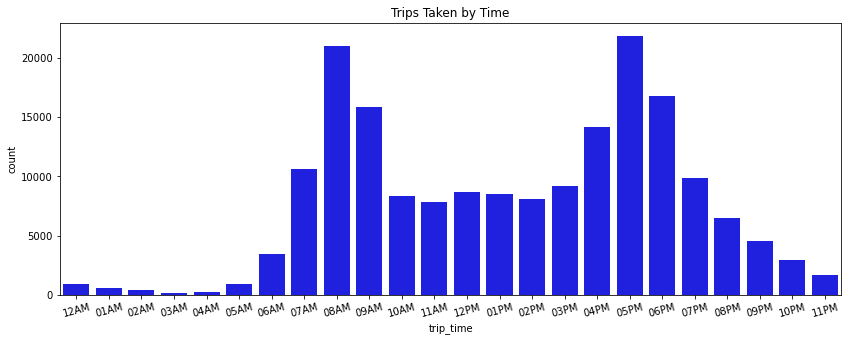

```python
#bar chart showing count of the time of day trips are taken

bar_plot(bike_clean, 'trip_time', 'Trips Taken by Time')
```

> Most trips are taken **5PM** and **8AM** as we can see from the chat above

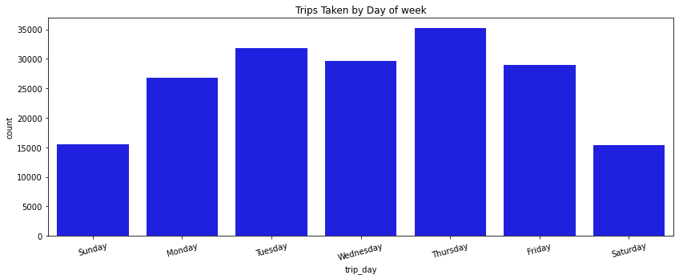

```python
#bar chart showing count of the day of week most trips are taken

bar_plot(bike_clean, 'trip_day', 'Trips Taken by Day of week')
```

> **Thursday** & **Tuesday** came out as the days when most trips are taken from the above chart

##### Does subscribers take more trip?

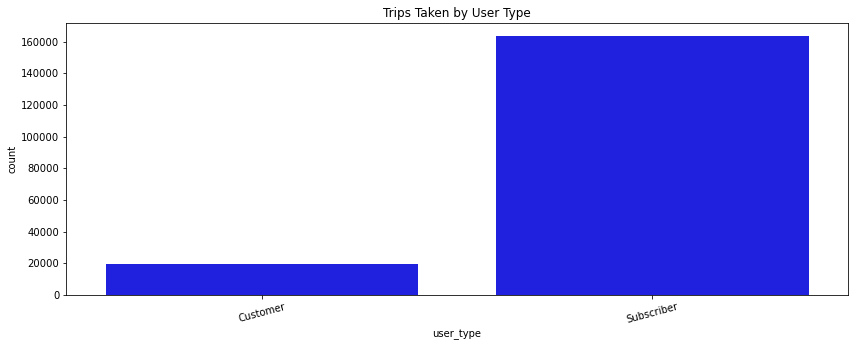

```python
#bar chart showing count of trips taken by subscribers/customers

bar_plot(bike_clean, 'user_type', 'Trips Taken by User Type')
```

```python
#function for value_counts pie chart

def pie_plot(data, col_name, title):
   data[col_name].value_counts().plot.pie(figsize = (5, 5))
   plt.title(title)
```

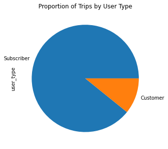

```python
#pie chart showing proportion of trips by subscribers & customers

pie_plot(bike_clean, 'user_type', 'Proportion of Trips by User Type')
```

> **Subscribers** are clearly taken the most trips as compared to Cusromers

##### What is the distribution of the trip durations like?

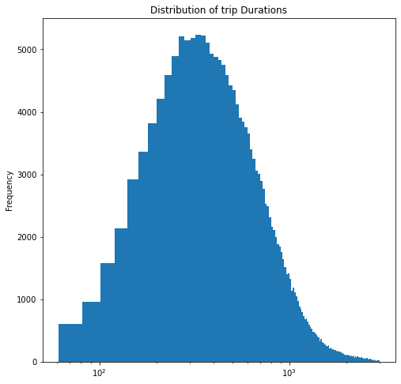

```python
#histogram with distribution of trip duration

min_sec = bike_clean['duration_sec'].min()
bins = np.arange(min_sec, 3000, 20)

bike_clean['duration_sec'].plot.hist(bins = bins, figsize = (8, 8))
plt.title('Distribution of trip Durations')
plt.xscale('log');
```

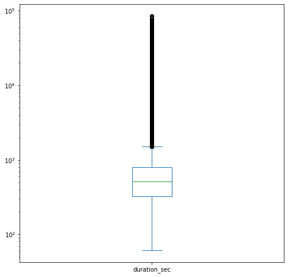

```python
#box plot of the duration of trips to show outliers

bike_clean['duration_sec'].plot.box(figsize = (8, 8))
plt.yscale('log');
```

> We can see a normal distributionwith quite a lot of outliers after using log transformation on the **duration_sec** data

##### What is the Distribution of Age like?

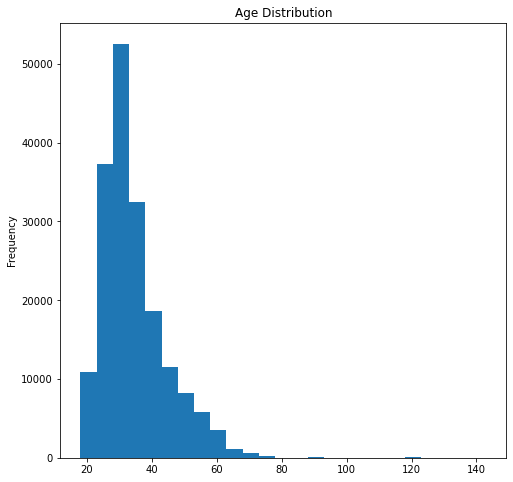

```python
#age distribution chart

min_age = bike_clean['age'].min()
max_age = bike_clean['age'].max()
bins = np.arange(min_age, max_age + 5, 5)
bike_clean['age'].plot.hist(bins = bins, figsize = (8, 8))
plt.title('Age Distribution');
```

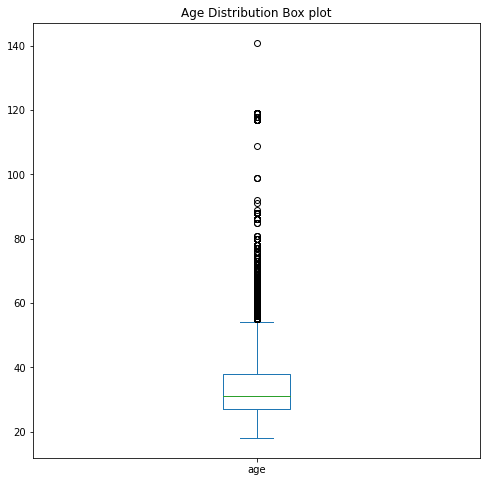

```python
#box plot for age distribution

bike_clean['age'].plot.box(figsize = (8, 8))
plt.title('Age Distribution Box plot');
```

> We can see that the distribution is rightly skewed with most of the age falling in between **20 - 50** years bucket and a few outliers

##### Does a particular gender take more trips?

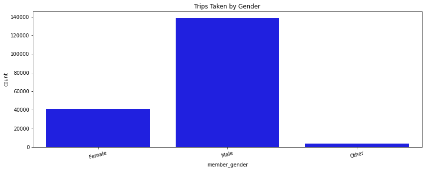

```python
#bar chart showing count of trips taken by each gender type

bar_plot(bike_clean, 'member_gender', 'Trips Taken by Gender')
```

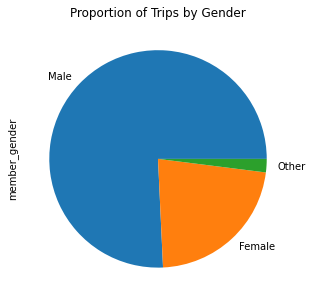

```python
#pie chart showing proportion of trips by gender type

pie_plot(bike_clean, 'member_gender', 'Proportion of Trips by Gender')
```

> **Male** are taking more trips than the other gender types in the dataset

##### Does a particular age group take more trips?

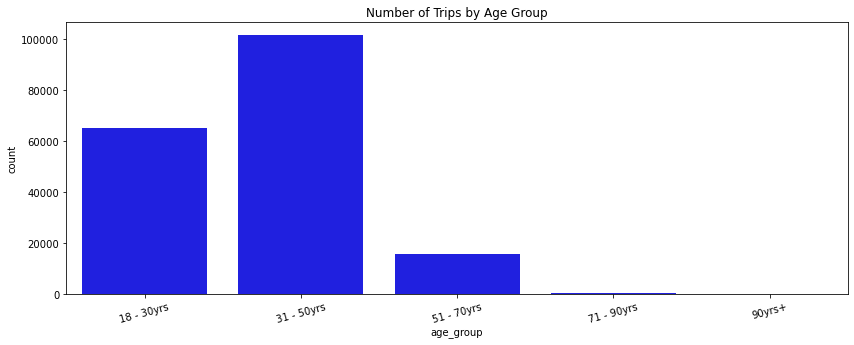

```python
#bar chart showing count of trips taken for each age group

bar_plot(bike_clean, 'age_group', 'Number of Trips by Age Group')
```

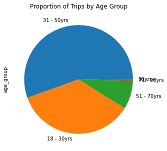

```python
#pie chart showing proportion of trips by age group

pie_plot(bike_clean, 'age_group', 'Proportion of Trips by Age Group')
```

> The **31 - 50yrs** & **18 - 50yrs** are taking the most trips

##### Do people who use bike share for all their trips take more trips?

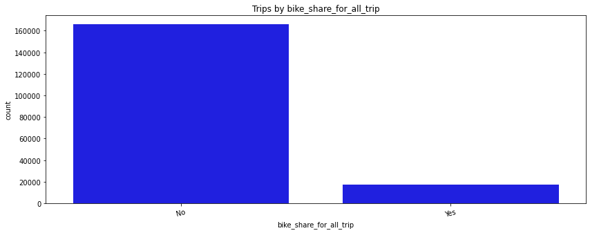

```python
#bar chart showing count of trips taken by people who used bike share for all their trips

bar_plot(bike_clean, 'bike_share_for_all_trip', 'Trips by bike_share_for_all_trip')
```

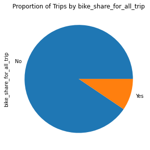

```python
#pie chart showing proportion of trips by bike_share_for_all_trip

pie_plot(bike_clean, 'bike_share_for_all_trip', 'Proportion of Trips by bike_share_for_all_trip')
```

> Most people dont use bike share for all their trips

### Important note during the Univariate exploration

> The distribution of the **duration_sec** column was highly skewed to the right so I had to use log transformation to reduce the skewness while keeping the outliers in the distribution. After the log transformation we can then see a normal distribution in the data, using the box plot also we can clearly see that there is quite a lot of outliers in the data also.

## Bivariate Exploration

> I'll be checking for relationships among two variables/features in this section

##### How long does the average trip take & Does it depend on if a user is a subscriber or customer?

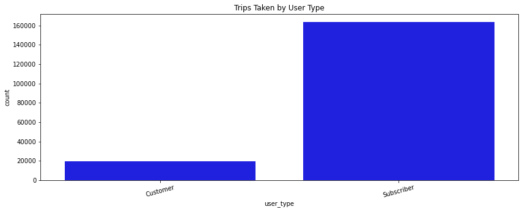

```python
#bar chart showing count of trips taken by subscribers/customers

bar_plot(bike_clean, 'user_type', 'Trips Taken by User Type')
```

```python
#creating a subset of the data

trip_by_user = bike_clean[['user_type', 'duration_sec']]

trip_by_user.head(3)
```

|  | user_type | duration_sec |
| --- | --- | --- |
| 0 | Customer | 52185 |
| 1 | Customer | 42521 |
| 2 | Customer | 61854 |

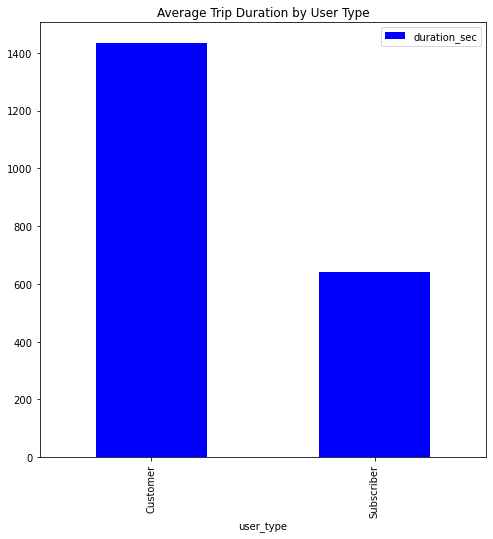

```python
#getting the average trip duration and plotting on a bar chart

trip_by_user.groupby('user_type').mean().plot.bar(figsize = (8, 8), color = 'blue')
plt.title('Average Trip Duration by User Type');
```

> Even though from the first chart we can see that Subscribers take more trips, On average **Customers** take a longer trip than Subscribers.

##### Does a particular age group subscribe more?

```python
#create a subset of the data

subscribers = bike_clean[bike_clean['user_type'] == 'Subscriber']

subscribers.head(3)
```

|  | duration_sec | start_time | end_time | start_station_id | start_station_name | end_station_id | end_station_name | bike_id | user_type | member_birth_year | member_gender | bike_share_for_all_trip | age | age_group | trip_day | trip_month | trip_time | trip_week |
| --- | --- | --- | --- | --- | --- | --- | --- | --- | --- | --- | --- | --- | --- | --- | --- | --- | --- | --- |
| 3 | 36490 | 2019-02-28 17:54:26.010 | 2019-03-01 04:02:36.842 | 375 | Grove St at Masonic Ave | 70 | Central Ave at Fell St | 6638 | Subscriber | 1989-01-01 | Other | No | 30 | 31 - 50yrs | Thursday | February | 05PM | Week 5 |
| 4 | 1585 | 2019-02-28 23:54:18.549 | 2019-03-01 00:20:44.074 | 7 | Frank H Ogawa Plaza | 222 | 10th Ave at E 15th St | 4898 | Subscriber | 1974-01-01 | Male | Yes | 45 | 31 - 50yrs | Thursday | February | 11PM | Week 5 |
| 5 | 1793 | 2019-02-28 23:49:58.632 | 2019-03-01 00:19:51.760 | 93 | 4th St at Mission Bay Blvd S | 323 | Broadway at Kearny | 5200 | Subscriber | 1959-01-01 | Male | No | 60 | 51 - 70yrs | Thursday | February | 11PM | Week 5 |

```python
#subset of the subscribers by age group

sub_age_group = subscribers[['user_type', 'age_group']]
```

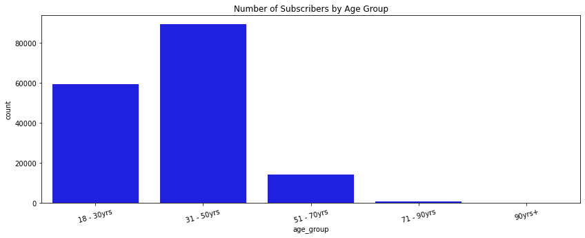

```python
#bar plot of number of subscribers by age group

bar_plot(sub_age_group, 'age_group', 'Number of Subscribers by Age Group')
```

> **31 - 50yrs** age group tend to subscribe more

##### Is there a particular time an age group take more trips?

```python
#subset of data

trip_time_age_group = bike_clean[['age_group', 'trip_time']]
trip_time_age_group.head(3)
```

|  | age_group | trip_time |
| --- | --- | --- |
| 0 | 31 - 50yrs | 05PM |
| 1 | 31 - 50yrs | 06PM |
| 2 | 31 - 50yrs | 12PM |

```python
#get count of trips for each trip_time and age_group

trip_time_age_group = trip_time_age_group.groupby(['age_group', 'trip_time']).size().reset_index(name = 'counts')

#get when most trips are taken by age group
trip_time_age_group = trip_time_age_group.loc[trip_time_age_group.groupby('age_group')['counts'].transform('max').eq(trip_time_age_group['counts'])]
trip_time_age_group
```

|  | age_group | trip_time | counts |
| --- | --- | --- | --- |
| 17 | 18 - 30yrs | 05PM | 7234 |
| 32 | 31 - 50yrs | 08AM | 12934 |
| 65 | 51 - 70yrs | 05PM | 1751 |
| 85 | 71 - 90yrs | 01PM | 73 |
| 114 | 90yrs+ | 06PM | 12 |

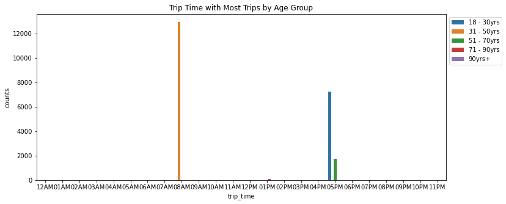

```python
#plot showing the number of trips for eah trip_time by age_group

plt.figure(figsize = (12, 5))

sns.barplot(data = trip_time_age_group, x = 'trip_time', y = "counts", hue = 'age_group')
plt.title('Trip Time with Most Trips by Age Group')
plt.legend(bbox_to_anchor=(1, 1));
```

> **31 - 50yrs** people make most trips by 8am in the morning followed by **18 - 20yrs** that take more trips in the evening at 5pm

##### Do trips taken in a particular time of day last longer?

```python
#create subset of the data

trip_time_duration = bike_clean[['trip_time', 'duration_sec']]

trip_time_duration.head(3)
```

|  | trip_time | duration_sec |
| --- | --- | --- |
| 0 | 05PM | 52185 |
| 1 | 06PM | 42521 |
| 2 | 12PM | 61854 |

```python
#get the average trip duration for each trip time

trip_time_duration = trip_time_duration.groupby('trip_time').mean().reset_index()
trip_time_duration = trip_time_duration.rename(columns = {'duration_sec': 'average_duration'}).sort_values(by = 'average_duration', ascending = False)

#view data
trip_time_duration.head(3)
```

|  | trip_time | average_duration |
| --- | --- | --- |
| 3 | 03AM | 1482.500000 |
| 2 | 02AM | 1177.765789 |
| 13 | 01PM | 885.689720 |

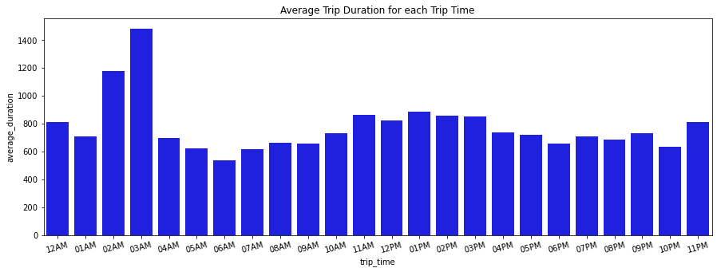

```python
#bar chart showing the average trip duration for each trip_time

plt.figure(figsize = (15, 5))
sns.barplot(data = trip_time_duration, x = 'trip_time', y = 'average_duration', color = 'blue')
plt.title('Average Trip Duration for each Trip Time')
plt.xticks(rotation = 15);
```

> It came as a surprise but on average longer trips were taken very very early in the morning by **3AM** & **2AM**

```python
#create subset of the data

trip_time_duration = bike_clean[['duration_sec']]

#For the trip_time I converted the trip hour to integers(in the 24hour format)
#so the correlation and scatterplot can be properly calculated

trip_time_duration['trip_time'] = pd.to_datetime(bike_clean['start_time']).dt.hour.astype(int)
trip_time_duration.head(3)
```

[output not shown]

|  | duration_sec | trip_time |
| --- | --- | --- |
| 0 | 52185 | 17 |
| 1 | 42521 | 18 |
| 2 | 61854 | 12 |

```python
#function for scatterplot

def scatter_plot(data, x, y, title):
    data.plot.scatter(y = y, x = x, figsize = (8, 8), marker = 'o', alpha = 0.1)
    plt.title(title)
```

##### Does age affect the duration of trips?

```python
#create a subset of the data

age_trip_duration = bike_clean[['age', 'duration_sec']]
age_trip_duration.head(3)
```

|  | age | duration_sec |
| --- | --- | --- |
| 0 | 35 | 52185 |
| 1 | 31 | 42521 |
| 2 | 47 | 61854 |

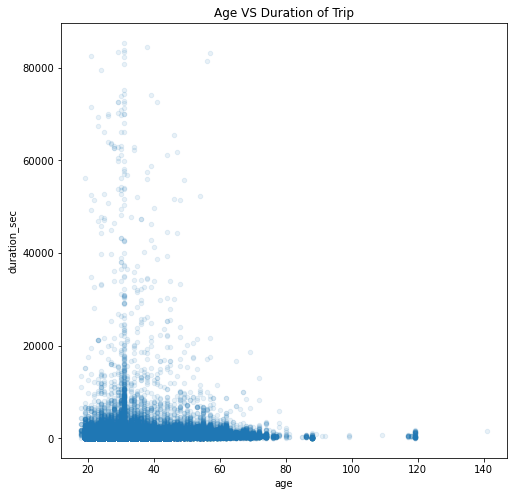

```python
#scatter plot for age vs duration_sec

scatter_plot(age_trip_duration, y = 'duration_sec', x = 'age', title = 'Age VS Duration of Trip')
```

```python
#correlation of age and trip duration

age_trip_duration.corr()
```

|  | age | duration_sec |
| --- | --- | --- |
| age | 1.000000 | 0.001631 |
| duration_sec | 0.001631 | 1.000000 |

> From the scatter plot and **correlation coefficient of 0.0016** it is safe to say there is no relationship between the duration of a trip and the age of the user

##### Does gender affect the trip duration?

```python
#create subset of data

gender_trip_duation = bike_clean[['member_gender', 'duration_sec']]
gender_trip_duation.head(3)
```

|  | member_gender | duration_sec |
| --- | --- | --- |
| 0 | Male | 52185 |
| 1 | Male | 42521 |
| 2 | Male | 61854 |

```python
#get average trip duration for each gender

gender_trip_duation = gender_trip_duation.groupby('member_gender').mean().sort_values(by = 'duration_sec', ascending = False).reset_index()
gender_trip_duation = gender_trip_duation.rename(columns = {'duration_sec': 'average_duration'})
gender_trip_duation
```

|  | member_gender | average_duration |
| --- | --- | --- |
| 0 | Other | 997.328489 |
| 1 | Female | 778.872761 |
| 2 | Male | 703.191614 |

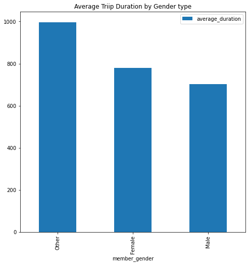

```python
#bar chart sshowing the average trip duration for gender

gender_trip_duation.plot.bar(x = 'member_gender', figsize = (8, 8))
plt.title('Average Triip Duration by Gender type');
```

> The **Other** gender has longer trips on average. But it came as a surprise personally to see **Female** as the gender with the second longest trip duration

##### What is the trend of trips over the weeks for: **user_type**, **member_gender** & **age_group**?

```python
#create a subset of data

trend = bike_clean.groupby(['user_type', 'member_gender', 'age_group', 'trip_week']).size().reset_index(name = 'trip_count')
trend.head(3)
```

|  | user_type | member_gender | age_group | trip_week | trip_count |
| --- | --- | --- | --- | --- | --- |
| 0 | Customer | Female | 18 - 30yrs | Week 1 | 277 |
| 1 | Customer | Female | 18 - 30yrs | Week 2 | 302 |
| 2 | Customer | Female | 18 - 30yrs | Week 3 | 605 |

```python
#function for trend_line

def trend_plot(category, title):

    plt.figure(figsize = (8, 8))
    sns.lineplot(data = trend, x = 'trip_week', y = 'trip_count', hue = category, ci = None)
    plt.title(title)
    plt.legend(bbox_to_anchor = (1, .5))
```

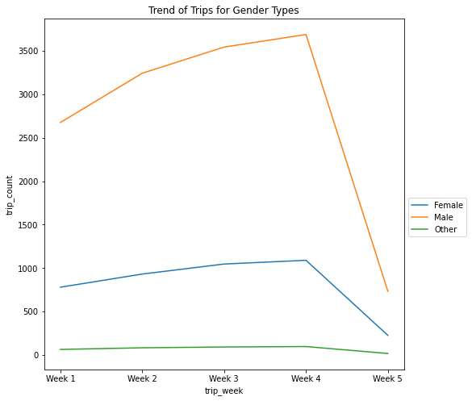

```python
#trend line for member_gender

trend_plot('member_gender', 'Trend of Trips for Gender Types')
```

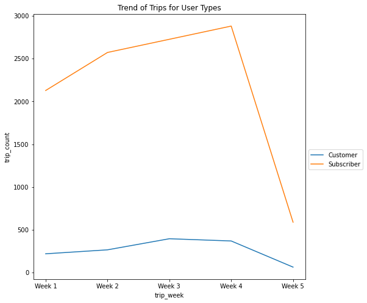

```python
#trend line for user_type

trend_plot('user_type', 'Trend of Trips for User Types')
```

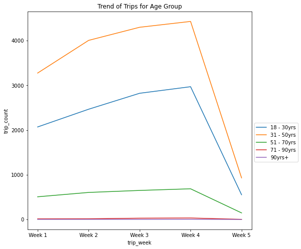

```python
#trend line for age_group

trend_plot('age_group', 'Trend of Trips for Age Group')
```

> Generally theres a downward trend from Week 4 or a decline in the total trips for the above variables

##### Does a particular **age_group** subscribe more?

```python
#create a subset of the data

age_sub = bike_clean.groupby(['age_group', 'user_type']).size().reset_index(name = 'counts').sort_values(by = 'counts', ascending = False)
age_sub.head(3)
```

|  | age_group | user_type | counts |
| --- | --- | --- | --- |
| 3 | 31 - 50yrs | Subscriber | 89260 |
| 1 | 18 - 30yrs | Subscriber | 59246 |
| 5 | 51 - 70yrs | Subscriber | 14262 |

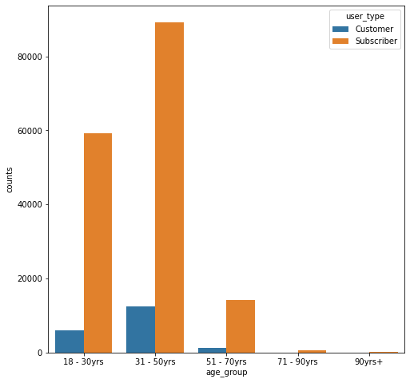

```python
#bar chart for subscriber count for each age_group

plt.figure(figsize = (8, 8))
sns.barplot(data = age_sub, x = 'age_group', y = 'counts', hue = 'user_type')
```

> **18 - 30yrs** & **31 - 50yrs** subscribe the most

### Interesting findings during Bivariate explorations

#### I observed that for:

##### user_type

- Even though Subscribers take more trips, On average **Customers** take a longer trip than Subscribers. ##### age
- Younger people between **18-50** years old subscribe more and even take more trips. ##### duration_sec
- No particular interesting relationship was found for the duration of trips as there was no correlation with the variables I measured

  ##### member_gender
- Interesting to see that Males have trips with lesser duration on average  
  ##### bike_share_for_all_trip
- Most of the trips are from people that dont take bike share for all trip ##### trip_day
- I hoped to see weekend with the most trips but the most trips were taken on **Thurdays** & **Tuesdays** ##### trip_time
- It's interesting to see that longer trips were in the middle of the night **3AM** & **2AM**

## Multivariate Exploration

> I'll be ccreating plots of three or more variables to investigate your data even further.

##### Is there a relationship between duration of trips and age?

```python
#function for scatterplot

def scatter_plot(data, x, y, hue, hue_color, title):
    data.plot.scatter(y = y, x = x, c = hue, colormap = hue_color, figsize = (8, 8))
    plt.title(title)
```

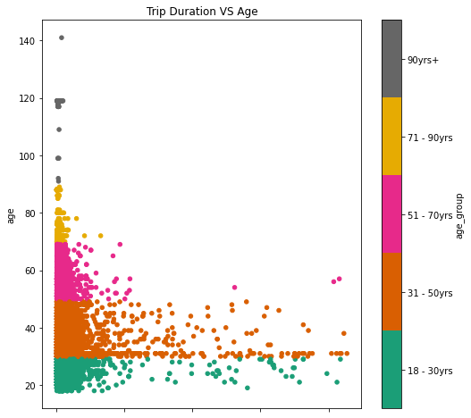

```python
#scatter plot for age vs duration of trips

scatter_plot(bike_clean, x = 'duration_sec', y = 'age', hue = 'age_group', hue_color = 'Dark2', title = 'Trip Duration VS Age')
```

> No strong correlation or relationship between age and duration of trips

##### No interesting relationships were observed, this is also because there's not many features with numerical data in the dataset for more multivariate exploration

## Conclusions

#### Here are my Reccommendations;

- The marketing team should target their ads/marketing campaign towards younger audience.
- Ford GoBike can find a means to add incentive to being a **Subscriber**, to encourage customers to become **Subscribers**.
- Ford GoBike can also create an app that records subscribers total trip duration and rewards them with free trips to encourage more usage.